# Panel Data and the New Diff-in-Diff

CML Week 9

2026-11-03

## Schedule

1. Design-based causal inference & Monte Carlo simulation
2. Covariate adjustment
3. Balancing weights
4. Double robustness, Double ML and TMLE
5. Heterogeneous Treatment Effects
6. HTE II: Neural Networks
7. Off-policy evaluation and optimization
8. Experimental design
9. **Panel data and the new diff-in-diff**
10. Partial Identification
11. Response adaptation
12. Interference

## Readings for Today

Foundational

- (Abadie, Diamond, and Hainmueller 2010): Synthetic control methods for comparative case studies

**Common**

- (Roth et al. 2023): What’s trending in difference-in-differences?

Presenter

- (Callaway and Sant’Anna 2021): Difference-in-differences with multiple time periods
- (Arkhangelsky et al. 2021): Synthetic difference-in-differences

## From experiments to observational panel data

**Last week:** Randomization ensures treatment assignment is independent of potential outcomes

**This week:** Can we get identification without randomization?

**The promise of panel data:**

- Observe units before and after treatment
- Use pre-treatment trends to infer counterfactual post-treatment outcomes
- “Parallel trends” replaces randomization

**The claim:** If treatment and control groups would have followed parallel trends absent treatment, differencing removes time-invariant confounding

**Spoiler:** This is harder than it looks!

# Difference-in-differences

## The canonical difference-in-differences

**Setup:** Two groups (treatment/control), two periods (pre/post)

|  | Pre $(t=0)$ | Post $(t=1)$ |
| --- | --- | --- |
| **Control** $(D=0)$ | $\bar{Y}_{00}$ | $\bar{Y}_{01}$ |
| **Treatment** $(D=1)$ | $\bar{Y}_{10}$ | $\bar{Y}_{11}$ |

**The DiD estimator:**

$$\hat{\tau}_{DiD} = (\bar{Y}_{11} - \bar{Y}_{10}) - (\bar{Y}_{01} - \bar{Y}_{00})$$

**Intuition:**

- First difference: change in treatment group
- Second difference: subtract change in control group (the counterfactual trend)
- Result: treatment effect, purged of common time trends

## Identification: What does parallel trends buy us?

**The fundamental problem:** We never observe $Y_{i1}(0)$ for treated units

**Parallel trends assumption:**

$$\mathbb{E}[Y_{i1}(0) - Y_{i0}(0) \mid D_i = 1] = \mathbb{E}[Y_{i1}(0) - Y_{i0}(0) \mid D_i = 0]$$

In words: *Absent treatment, treated and control groups would have experienced the same average change*

**What this gives us:**

$$\begin{align}
\mathbb{E}[Y_{i1}(0) \mid D_i = 1] &= \mathbb{E}[Y_{i0}(0) \mid D_i = 1] + \mathbb{E}[Y_{i1}(0) - Y_{i0}(0) \mid D_i = 0] \\
&= \text{(observed)} + \text{(observed)}
\end{align}$$

The counterfactual is identified! We can estimate the ATT:

$$\tau_{ATT} = \mathbb{E}[Y_{i1}(1) - Y_{i1}(0) \mid D_i = 1]$$

## The hardness of parallel trends

**The core problem:** Parallel trends is an assumption about *counterfactuals*

$$\mathbb{E}[Y_{i1}(0) - Y_{i0}(0) \mid D_i = 1] = \mathbb{E}[Y_{i1}(0) - Y_{i0}(0) \mid D_i = 0]$$

We never observe $Y_{i1}(0)$ for treated units $\implies$ fundamentally untestable

**What we’re really assuming:**

- Treatment and control have the same unobserved time-varying factors
- Selection into treatment based only on:
  - Time-invariant differences (removed by differencing)
  - Observed time-varying factors (can condition on these)
- *No time-varying unobserved confounders that differ by group*

This is strong! Requires that all differential trends are due to treatment, not selection

## Testing and falsification

**Can we test parallel trends?** Not directly, but we can check *pre-trends*

**Pre-trends test:** Do treatment and control have parallel trends *before* treatment?

- If yes: suggests parallel trends might hold post-treatment
- If no: parallel trends assumption is likely violated

**The logic:** If trends differ pre-treatment, why would they be parallel post-treatment?

**Limitations:**

- Pre-trends can pass even when parallel trends fails
  - Example: Firms change behavior *before* policy announcement, masking differential pre-trends
- Pre-trends can fail even when parallel trends holds
  - Example: Treatment targets units with temporarily low outcomes; pre-trends diverge but would have converged absent treatment
- Limited pre-treatment periods $\implies$ low statistical power
- Absence of evidence $\neq$ evidence of absence

**Bottom line:** Pre-trends are good but not determinative of parallel trends

## When is parallel trends sensitive to functional form? (Roth and Sant’Anna 2023)

**The insight:** Parallel trends can hold in one scale but not another

**Example:** Consider earnings $Y$ and log earnings $\log(Y)$

- Levels: $\mathbb{E}[Y_{t}(0) - Y_{t-1}(0) \mid D=1] = \mathbb{E}[Y_{t}(0) - Y_{t-1}(0) \mid D=0]$
- Logs: $\mathbb{E}[\log Y_{t}(0) - \log Y_{t-1}(0) \mid D=1] = \mathbb{E}[\log Y_{t}(0) - \log Y_{t-1}(0) \mid D=0]$

These cannot both be true! (except in degenerate cases)

**The problem:**

- Parallel trends in levels $\implies$ constant additive differences
- Parallel trends in logs $\implies$ constant multiplicative differences
- Your choice of scale is an *untestable assumption*

**Why randomization is different:** With random treatment assignment, $D \perp (Y(0), Y(1))$ holds in *all* functional forms

- Independence is scale-invariant

## When does DiD go wrong?

**The setting:** Multiple groups, staggered treatment adoption

**Two-way fixed effects (TWFE) regression:**

$$Y_{it} = \alpha_i + \lambda_t + \tau D_{it} + \epsilon_{it}$$

**The promise:** $\hat{\tau}$ estimates the average treatment effect

**The problems:**

1. **Heterogeneous treatment effects:** If effects vary across groups/time, TWFE is a *weighted average* with potentially negative weights (De Chaisemartin and d’Haultfoeuille 2020)
2. **Forbidden comparisons:** TWFE compares already-treated units to newly-treated units, which violates parallel trends (Goodman-Bacon 2021)
3. **The result:** $\hat{\tau}$ can be biased, even with the sign flipped!

**Bottom line:** Basic TWFE with staggered adoption can be perilous

# (Goodman-Bacon 2021)

## Three timing groups

Early group $k$, late group $\ell$, never-treated group $U$. Effects are constant: $10$ for $k$, $15$ for $\ell$.

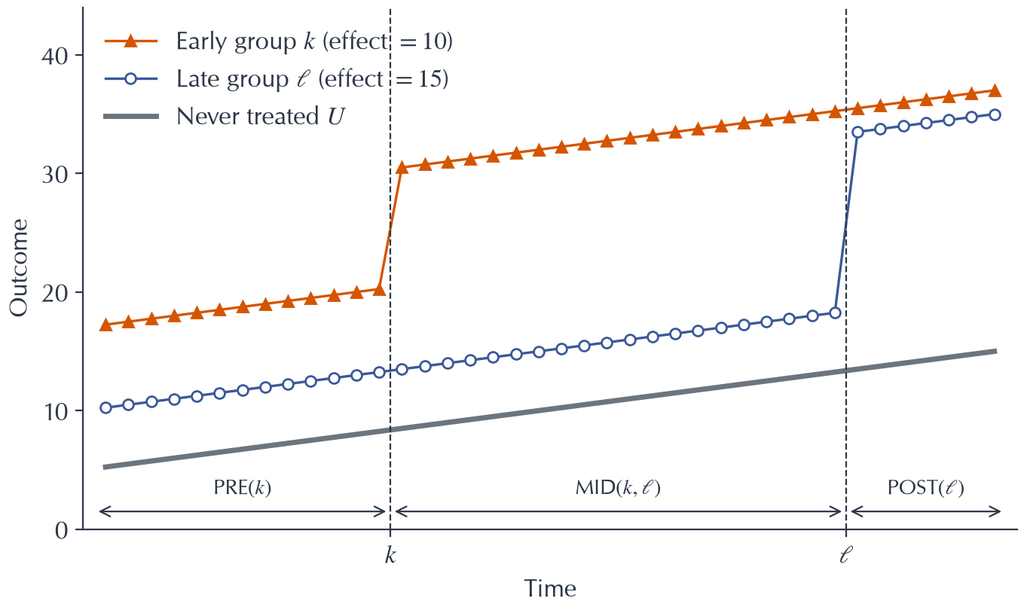

## TWFE is an average of 2x2s

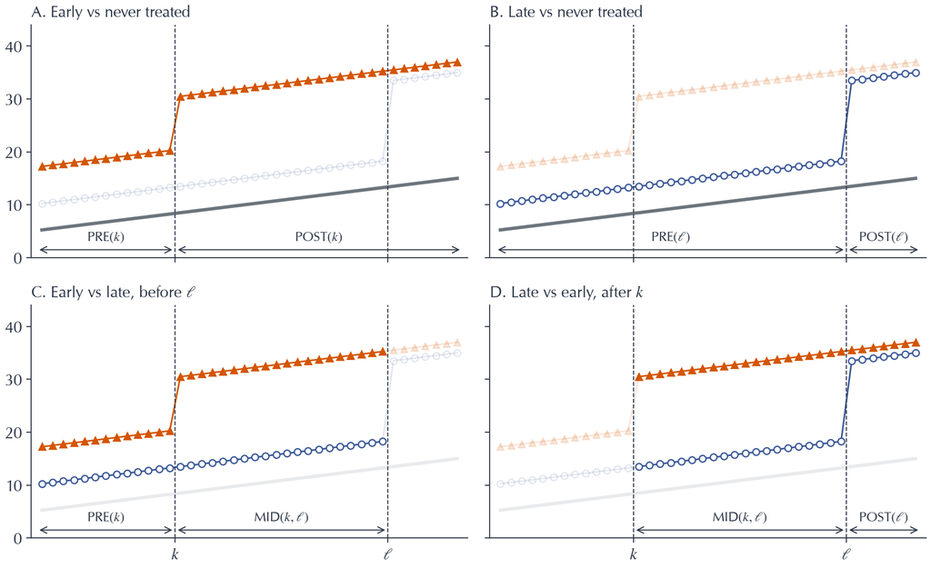

**Theorem:** $\hat{\tau}_{TWFE} = \sum s \cdot \hat{\beta}^{2\times 2}$ over all four comparisons, with weights $s \geq 0$, $\sum s = 1$, set by group sizes and the variance of $D_{it}$ in each window

## The forbidden comparison

Panel D uses the already-treated group $k$ as the control for $\ell$. Under parallel trends:

$$\hat{\beta}^{2\times 2, \ell}_{k\ell} \to ATT_\ell(\text{POST}) - \big[ATT_k(\text{POST}) - ATT_k(\text{MID})\big]$$

- Constant effects: the bracket is zero, and panel D is fine
- Effects that grow with exposure: the growth in $k$’s effect is subtracted from $\ell$’s

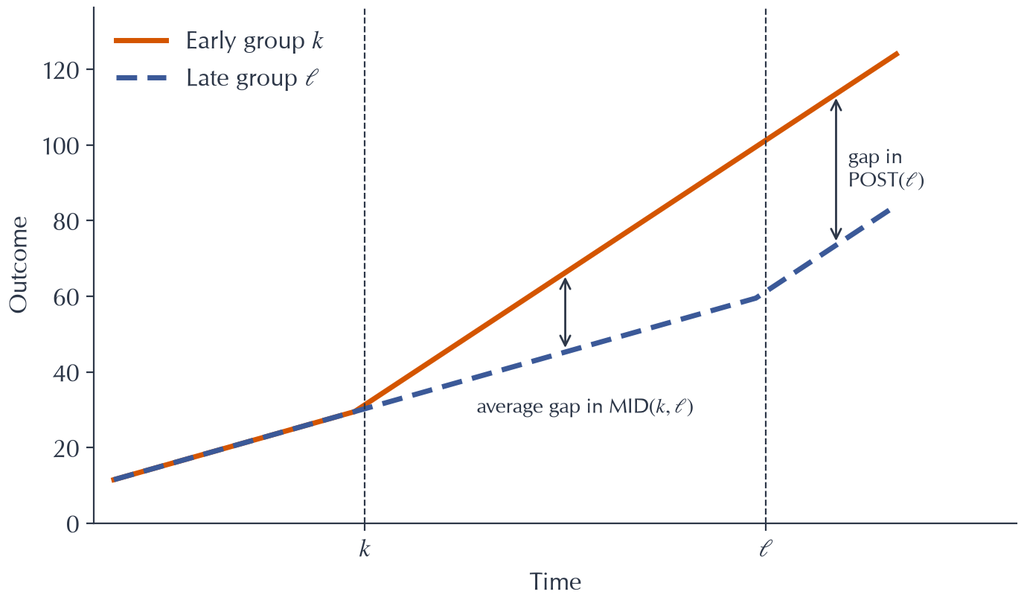

## The decomposition, simulated

Parallel trends holds. Every unit’s effect is positive and grows by $1$ per period of exposure.

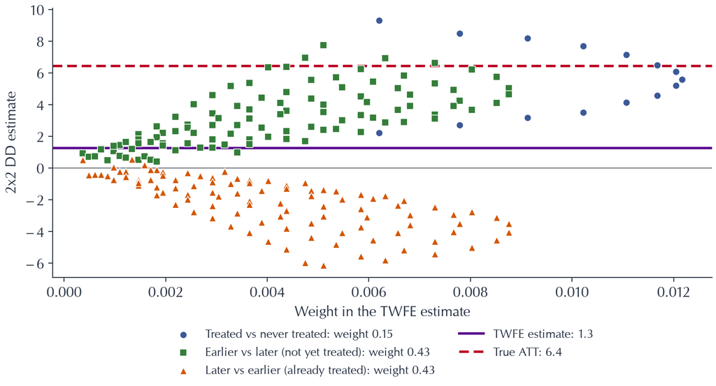

Every weight is positive; the later vs earlier 2x2s go negative. This is where the negative weights of (De Chaisemartin and d’Haultfoeuille 2020) come from

# (Callaway and Sant’Anna 2021)

## Modern solutions

**The key insight:** Avoid forbidden comparisons by using never-treated units as controls (Callaway and Sant’Anna 2021; Sun and Abraham 2021)

**Group-time ATTs:** Estimate treatment effects for each cohort $g$ at each time $t$:

$$ATT(g,t) = \mathbb{E}[Y_{it}(1) - Y_{it}(0) \mid G_i = g]$$

where $G_i$ is the period when unit $i$ first receives treatment

**Aggregation:** Combine group-time ATTs to get target parameters:

- Overall ATT: weighted average across all $(g,t)$
- Dynamic effects: average by event time $t - g$
- Group-specific effects: average over time for each $g$

**Advantages:** Valid inference, handles heterogeneity, avoids negative weights

## Identifying $ATT(g,t)$

**No anticipation:** $Y_{it} = Y_{it}(0)$ for all $t < G_i$

**Parallel trends, cohort by cohort:** with $C_i = 1$ for never-treated units,

$$\mathbb{E}[Y_t(0) - Y_{t-1}(0) \mid G = g] = \mathbb{E}[Y_t(0) - Y_{t-1}(0) \mid C = 1]$$

**Then each $ATT(g,t)$ is one clean 2x2**, with base period $g - 1$:

$$ATT(g,t) = \mathbb{E}[Y_t - Y_{g-1} \mid G = g] - \mathbb{E}[Y_t - Y_{g-1} \mid C = 1]$$

- Controls are never treated: no already-treated unit is ever a control
- Alternative: use the not yet treated ($G_i > t$) as controls, a larger comparison group
- With covariates, each 2x2 can be estimated by outcome regression, IPW, or the doubly robust estimator from Week 4

## Group-time ATTs in a picture

Same kind of growing effect, three cohorts plus a never-treated group

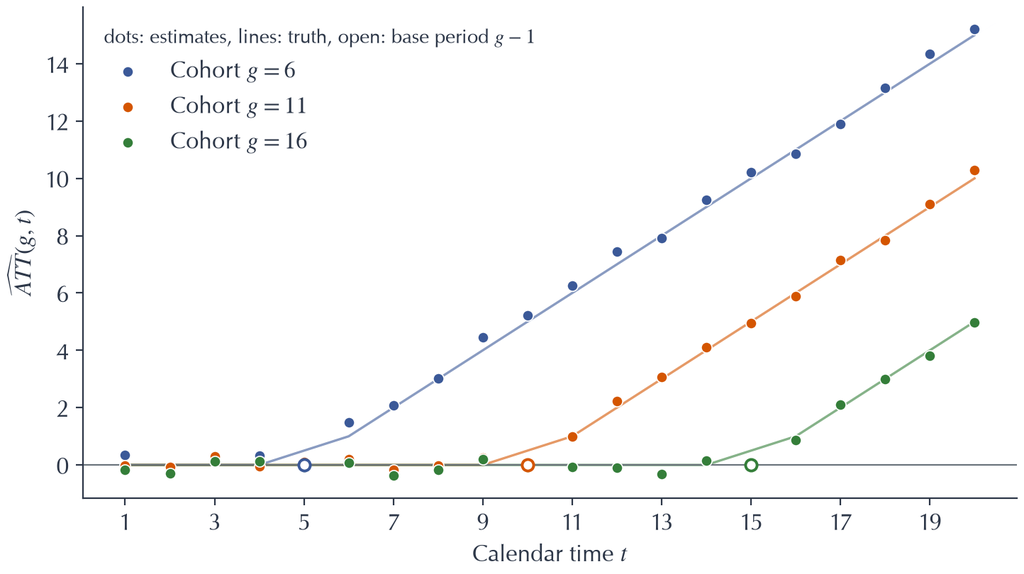

- Points before $g - 1$ are placebo estimates: a pre-trends check, cohort by cohort

## Aggregating group-time ATTs

The analyst chooses the weights, and they are never negative

**By event time** (an event study), over the cohorts observed $e$ periods after adoption:

$$\theta(e) = \sum_{g} \Pr(G = g \mid g + e \leq T)\, ATT(g, g + e)$$

**By cohort:**

$$\theta(g) = \frac{1}{T - g + 1} \sum_{t \geq g} ATT(g, t)$$

**Overall:** average $\theta(g)$ with weights $\Pr(G = g \mid G \leq T)$

- Long horizons $e$ come from early cohorts only: the mix of cohorts changes with $e$

## Event study: group-time ATTs vs TWFE

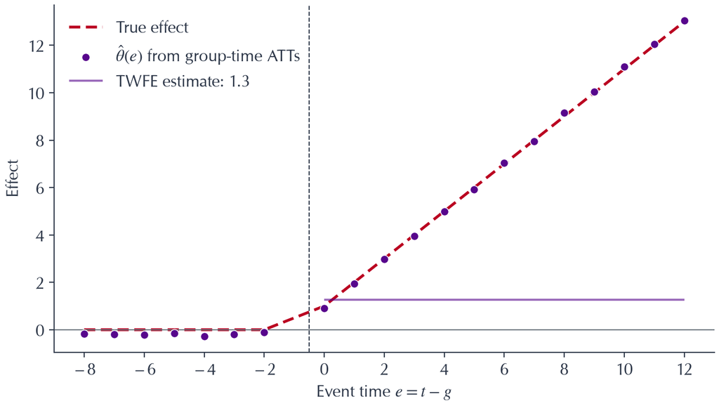

Same simulated panel as the decomposition: true ATT $6.4$, TWFE $1.3$

# (Abadie, Diamond, and Hainmueller 2010)

## Synthetic controls: Focusing on parallel trends

**The motivation:** What if parallel trends doesn’t hold for *any* single control unit?

**Classic example:** Effect of California’s tobacco control program (Prop 99, 1988) (Abadie, Diamond, and Hainmueller 2010)

- One treated unit (California)
- Many potential control states (almost 50, in fact)
- But no single state is a good match for California

**The insight:** Create a *synthetic California* from other states

## The synthetic control method

**Setup:** One treated unit, $J$ control units (the “donor pool”)

**Goal:** Find weights $w_j \geq 0$ with $\sum_j w_j = 1$ such that:

$$\sum_{j=2}^{J+1} w_j Y_{jt} \approx Y_{1t} \quad \text{for all pre-treatment periods } t < T_0$$

**How to find weights:** Solve optimization problem

$$\min_{w} \sum_{t<T_0} \left(Y_{1t} - \sum_j w_j Y_{jt}\right)^2 \quad \text{subject to } w_j \geq 0, \sum_j w_j = 1$$

- Why $w_j \geq 0$?
- Why $\sum_j w_j = 1$?

**Identification:** If it matches trends pre-treatment, maybe also post-treatment?

## Why synthetic control works

**Key assumption:** The outcome follows a factor model

$$Y_{it} = \delta_t + \theta_t Z_i + \lambda_t \mu_i + \epsilon_{it}$$

where $\delta_t$ are time effects, $Z_i$ are observed covariates, $\mu_i$ are unobserved factors

**If weights reproduce:**

- Pre-treatment outcomes
- Pre-treatment covariates
- And we have enough pre-treatment periods

**Then:** The weighted control units have the same $\mu_i$ as the treated unit

**Result:** $\sum_j w_j^* Y_{jt}$ is an unbiased estimate of $Y_{1t}(0)$ post-treatment

**Extensions:** Augmented SC (Ben-Michael, Feller, and Rothstein 2021) adds outcome modeling for robustness

## Synthetic control as an event study

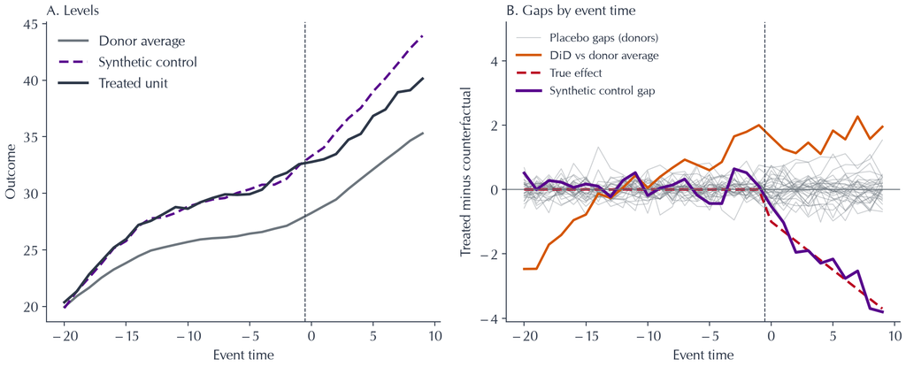

- **Before:** the SC gap sits in the placebo band; DiD shows a pre-trend
- **After:** the SC gap tracks the true effect; DiD gets the sign wrong
- **Inference:** is the treated gap extreme among the donor placebos?

# Synthesis

## The evolution of diff-in-diff methods

**Classic DiD (pre-2000s):** 2x2 design with parallel trends assumption

- Simple and intuitive, but limited to two groups and two periods

**TWFE era (2000s-2010s):** Panel data with unit and time fixed effects

- Became the workhorse of applied econometrics

**The reckoning (2018-2021):** Discovery of fundamental problems

- Forbidden comparisons, negative weights, functional form sensitivity

**Modern solutions (2020s):** New estimation strategies

- Group-time aggregation, synthetic controls, sensitivity analysis

**The lesson:** Even “simple” methods hide complex assumptions

# References

Abadie, Alberto, Alexis Diamond, and Jens Hainmueller. 2010. “Synthetic Control Methods for Comparative Case Studies: Estimating the Effect of California’s Tobacco Control Program.” *Journal of the American Statistical Association* 105 (490): 493–505.

Arkhangelsky, Dmitry, Susan Athey, David A Hirshberg, Guido W Imbens, and Stefan Wager. 2021. “Synthetic Difference-in-Differences.” *American Economic Review* 111 (12): 4088–118.

Ben-Michael, Eli, Avi Feller, and Jesse Rothstein. 2021. “The Augmented Synthetic Control Method.” *Journal of the American Statistical Association* 116 (536): 1789–1803.

Callaway, Brantly, and Pedro HC Sant’Anna. 2021. “Difference-in-Differences with Multiple Time Periods.” *Journal of Econometrics* 225 (2): 200–230.

De Chaisemartin, Clément, and Xavier d’Haultfoeuille. 2020. “Two-Way Fixed Effects Estimators with Heterogeneous Treatment Effects.” *American Economic Review* 110 (9): 2964–96.

Goodman-Bacon, Andrew. 2021. “Difference-in-Differences with Variation in Treatment Timing.” *Journal of Econometrics* 225 (2): 254–77.

Roth, Jonathan, and Pedro HC Sant’Anna. 2023. “When Is Parallel Trends Sensitive to Functional Form?” *Econometrica* 91 (2): 737–47.

Roth, Jonathan, Pedro HC Sant’Anna, Alyssa Bilinski, and John Poe. 2023. “What’s Trending in Difference-in-Differences? A Synthesis of the Recent Econometrics Literature.” *Journal of Econometrics* 235 (2): 2218–44.

Sun, Liyang, and Sarah Abraham. 2021. “Estimating Dynamic Treatment Effects in Event Studies with Heterogeneous Treatment Effects.” *Journal of Econometrics* 225 (2): 175–99.